# College Admission

### Clearing the r environment

```r
rm(list = ls(all = TRUE))
```

### Reading the College Admission csv file

```r
CA <- read.csv('College_admission.csv', header = T, na.strings = c("NA","","?"," "))
```

### Exploratory Data Analysis

```r
head(CA)
```

```
##   admit gre  gpa ses Gender_Male Race rank
## 1     0 380 3.61   1           0    3    3
## 2     1 660 3.67   2           0    2    3
## 3     1 800 4.00   2           0    2    1
## 4     1 640 3.19   1           1    2    4
## 5     0 520 2.93   3           1    2    4
## 6     1 760 3.00   2           1    1    2
```

```r
tail(CA)
```

```
##     admit gre  gpa ses Gender_Male Race rank
## 395     1 460 3.99   3           1    3    3
## 396     0 620 4.00   2           0    2    2
## 397     0 560 3.04   2           0    1    3
## 398     0 460 2.63   3           0    2    2
## 399     0 700 3.65   1           1    1    2
## 400     0 600 3.89   2           1    3    3
```

```r
str(CA)
```

```
## 'data.frame':    400 obs. of  7 variables:
##  $ admit      : int  0 1 1 1 0 1 1 0 1 0 ...
##  $ gre        : int  380 660 800 640 520 760 560 400 540 700 ...
##  $ gpa        : num  3.61 3.67 4 3.19 2.93 3 2.98 3.08 3.39 3.92 ...
##  $ ses        : int  1 2 2 1 3 2 2 2 1 1 ...
##  $ Gender_Male: int  0 0 0 1 1 1 1 0 1 0 ...
##  $ Race       : int  3 2 2 2 2 1 2 2 1 2 ...
##  $ rank       : int  3 3 1 4 4 2 1 2 3 2 ...
```

```r
summary(CA)
```

```
##      admit             gre             gpa             ses
##  Min.   :0.0000   Min.   :220.0   Min.   :2.260   Min.   :1.000
##  1st Qu.:0.0000   1st Qu.:520.0   1st Qu.:3.130   1st Qu.:1.000
##  Median :0.0000   Median :580.0   Median :3.395   Median :2.000
##  Mean   :0.3175   Mean   :587.7   Mean   :3.390   Mean   :1.992
##  3rd Qu.:1.0000   3rd Qu.:660.0   3rd Qu.:3.670   3rd Qu.:3.000
##  Max.   :1.0000   Max.   :800.0   Max.   :4.000   Max.   :3.000
##   Gender_Male         Race            rank
##  Min.   :0.000   Min.   :1.000   Min.   :1.000
##  1st Qu.:0.000   1st Qu.:1.000   1st Qu.:2.000
##  Median :0.000   Median :2.000   Median :2.000
##  Mean   :0.475   Mean   :1.962   Mean   :2.485
##  3rd Qu.:1.000   3rd Qu.:3.000   3rd Qu.:3.000
##  Max.   :1.000   Max.   :3.000   Max.   :4.000
```

### By looking at the variables we can identify continuous variables and categorical variables

### categorical variables : SES, Gender, Race, Rank

### Continuous variables : GRE, GPA

### Target Variable : Admit

### Before we perfrom some analysis, we need to change the datatype of certain variables

#### These are the Variables that need data type conversion

## 3. Find the structure of the data set and if required, transform the numeric data type to factor and vice-versa.

```r
CA$admit <- as.factor(CA$admit)
CA$ses <- as.factor(CA$ses)
CA$Gender_Male <- as.factor(CA$Gender_Male)
CA$Race <- as.factor(CA$Race)
CA$rank <- as.factor(CA$rank)
str(CA)
```

```
## 'data.frame':    400 obs. of  7 variables:
##  $ admit      : Factor w/ 2 levels "0","1": 1 2 2 2 1 2 2 1 2 1 ...
##  $ gre        : int  380 660 800 640 520 760 560 400 540 700 ...
##  $ gpa        : num  3.61 3.67 4 3.19 2.93 3 2.98 3.08 3.39 3.92 ...
##  $ ses        : Factor w/ 3 levels "1","2","3": 1 2 2 1 3 2 2 2 1 1 ...
##  $ Gender_Male: Factor w/ 2 levels "0","1": 1 1 1 2 2 2 2 1 2 1 ...
##  $ Race       : Factor w/ 3 levels "1","2","3": 3 2 2 2 2 1 2 2 1 2 ...
##  $ rank       : Factor w/ 4 levels "1","2","3","4": 3 3 1 4 4 2 1 2 3 2 ...
```

## 1. Find the missing values. (if any, perform missing value treatment).

### Checking for Null values.

```r
sum(is.na(CA))
```

```
## [1] 0
```

### Since there are no Null values in the dataset, imputation is not required

## 2. Find outliers (if any, then perform outlier treatment).

### Visualizing continuous variables

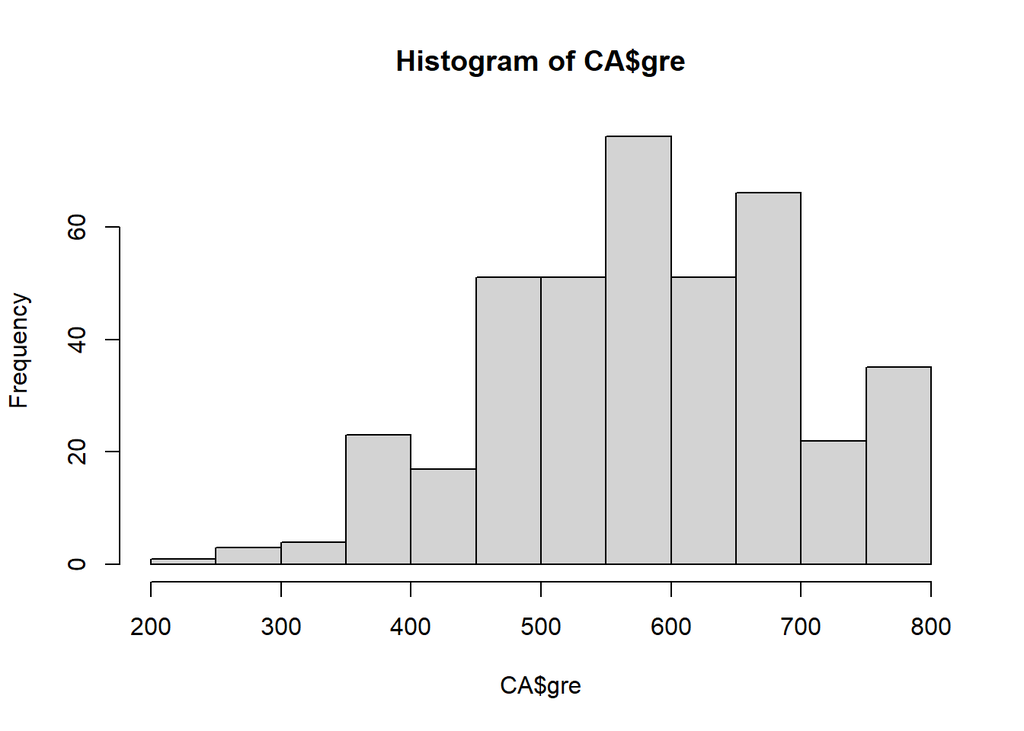

```r
hist(CA$gre)
```

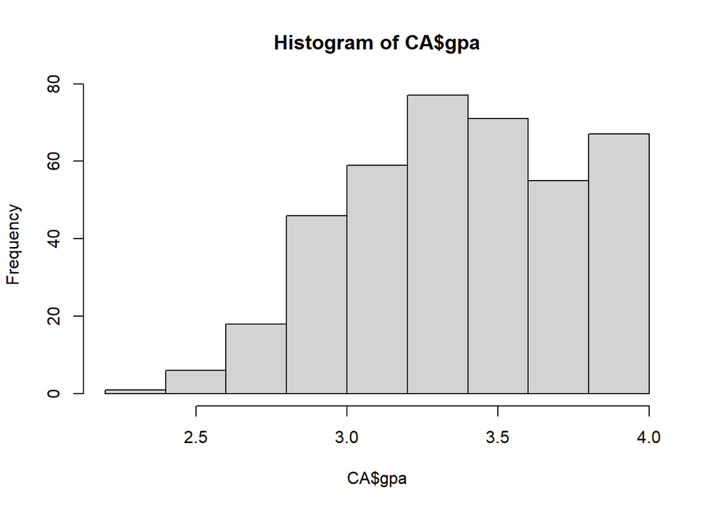

```r
hist(CA$gpa)
```

```r
summary(CA$gre)
```

```
##    Min. 1st Qu.  Median    Mean 3rd Qu.    Max.
##   220.0   520.0   580.0   587.7   660.0   800.0
```

#### By looking at the summary, we can see a huge difference between min and max value

### Using Boxplot to understand if there are any outliers present in the dataset

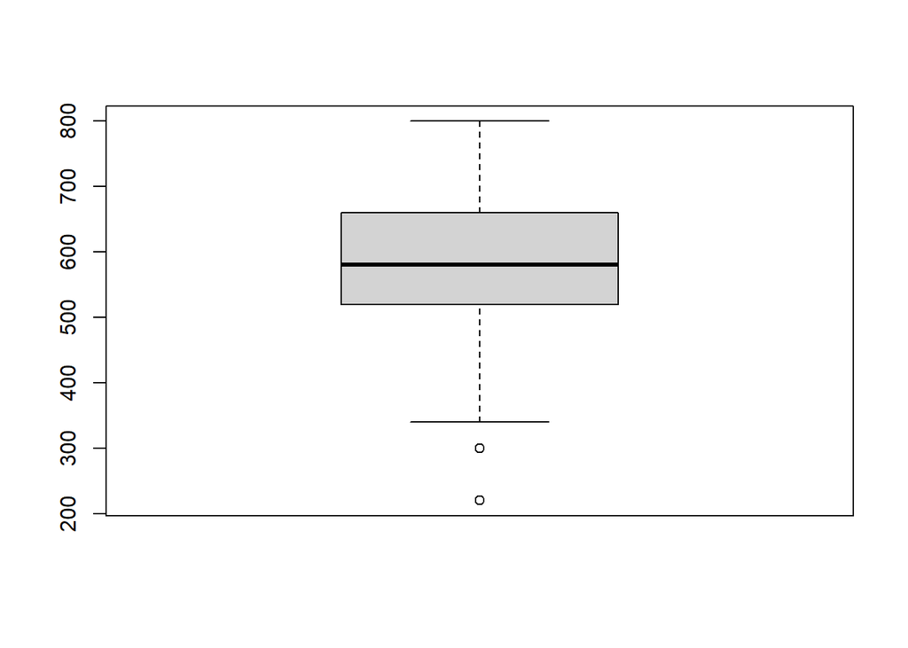

```r
boxplot(CA$gre, horizontal = F)
```

### By looking at the Boxplot, we can see there are outliers in the data

#### Drawing abline

```r
levels(cut(CA$gre, breaks = 10, include.lowest = T))
```

```
##  [1] "[219,278]" "(278,336]" "(336,394]" "(394,452]" "(452,510]" "(510,568]"
##  [7] "(568,626]" "(626,684]" "(684,742]" "(742,801]"
```

```r
min(CA$gre)
```

```
## [1] 220
```

```r
max(CA$gre)
```

```
## [1] 800
```

```r
Q1 <- quantile(CA$gre, 0.25)
Q1
```

```
## 25%
## 520
```

```r
Q3 <- quantile(CA$gre, 0.75)
Q3
```

```
## 75%
## 660
```

```r
iqr <- IQR(CA$gre)
iqr
```

```
## [1] 140
```

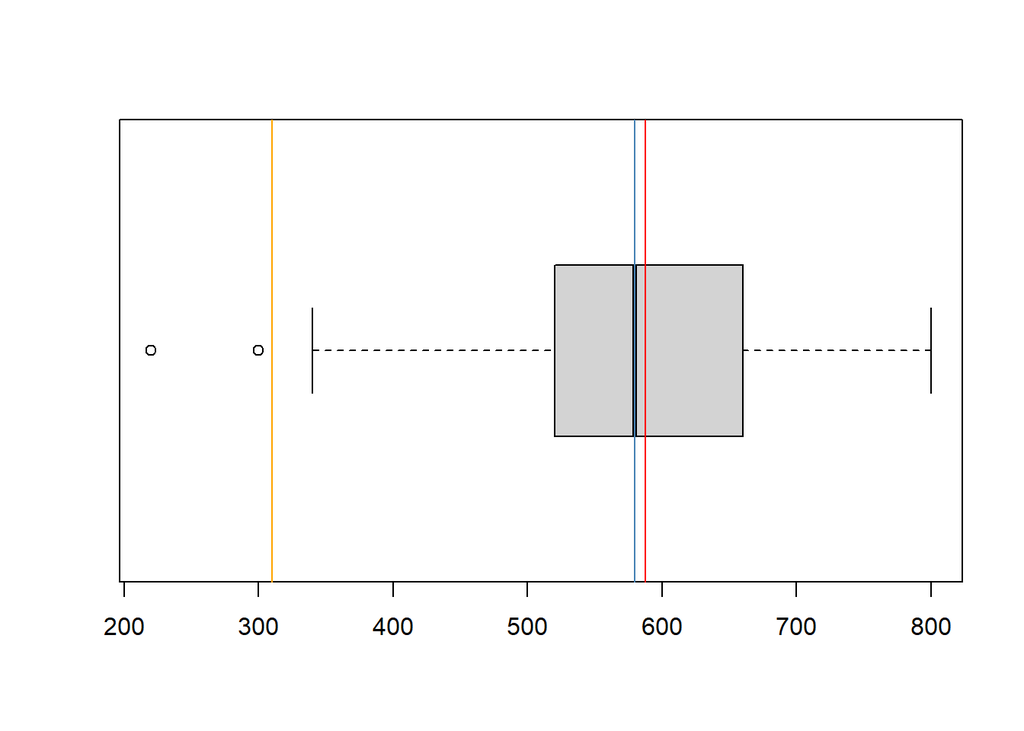

```r
boxplot(CA$gre, horizontal = T)
abline(v = c(mean(CA$gre), median(CA$gre),
             Q1 -(1.5 * iqr), Q3 + (1.5 * iqr)),
             col = c('red', 'steelblue','orange','magenta'))
```

### Now let’s look at the outliers

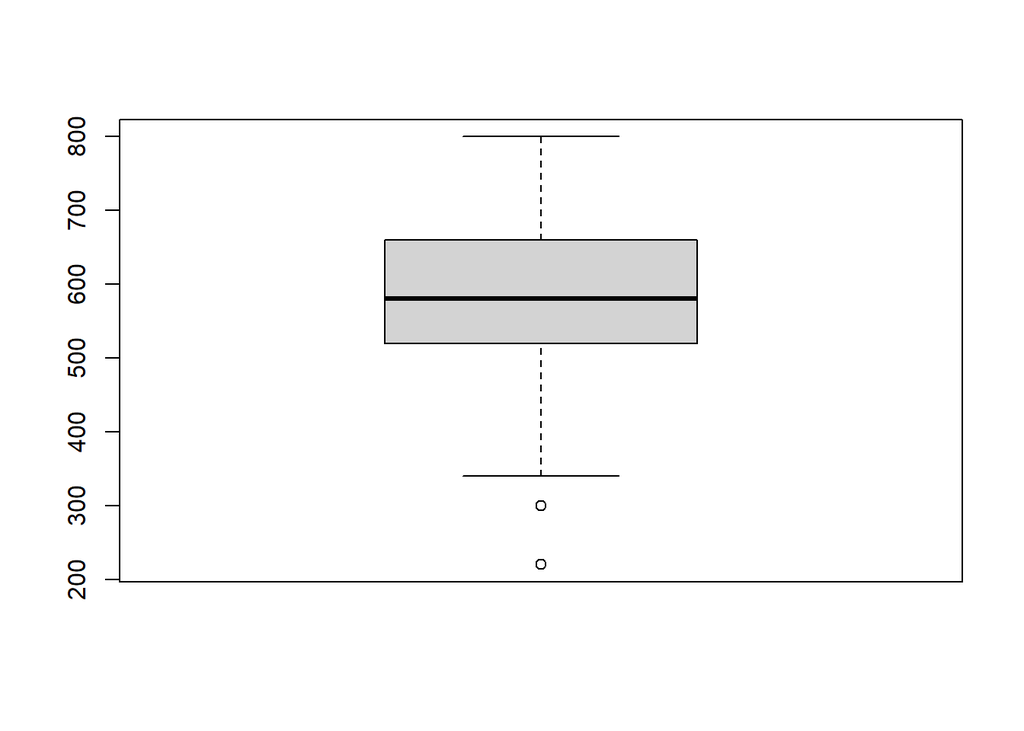

```r
greoutlier <- boxplot(CA$gre)$out
```

### Outliers, No. of outliers present in that column and the index of the outliers

```r
greoutlier
```

```
## [1] 300 300 220 300
```

```r
length(greoutlier)
```

```
## [1] 4
```

```r
which(CA$gre %in% greoutlier)
```

```
## [1]  72 180 305 316
```

### So, there are 4 outliers present in the GRE variable.

### We can perform the following to treat outliers

#### 1. Drop the Outliers

#### 2. Transform the data

#### 3. Impute them by their mean

#### But since there are very few outliers we can simply drop those rows

### Removing outliers from GRE variable

```r
# CA$gre[ !(CA$gre %in%greoutlier) ]
```

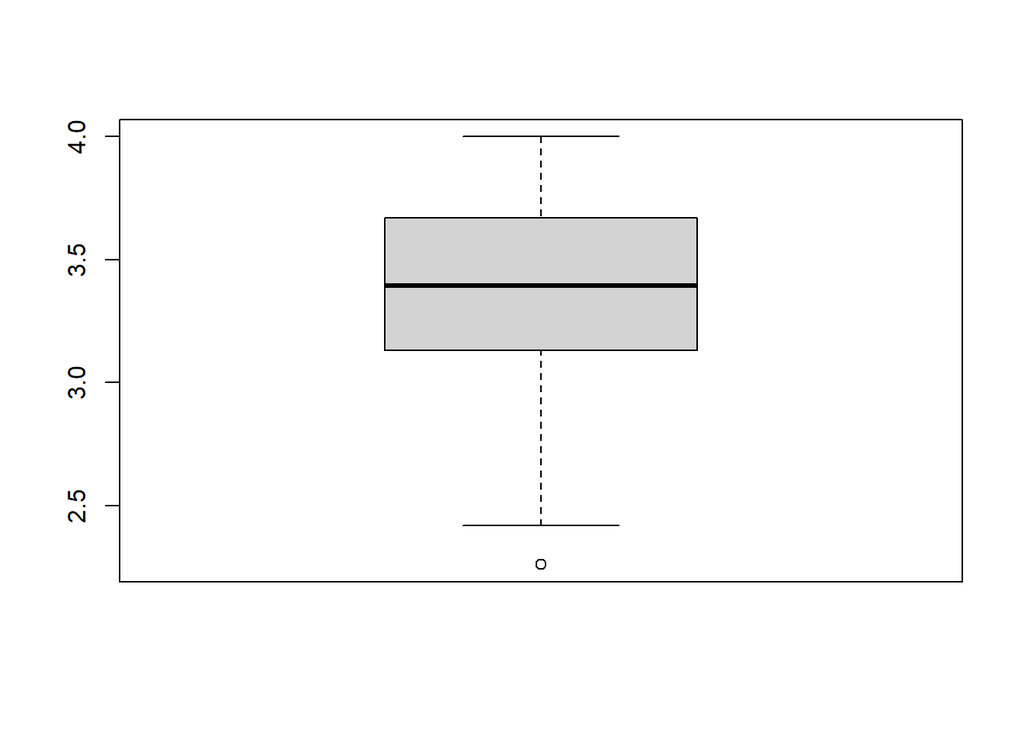

```r
gpaoutlier <- boxplot(CA$gpa)$out
```

```r
gpaoutlier
```

```
## [1] 2.26
```

```r
length(gpaoutlier)
```

```
## [1] 1
```

```r
which(CA$gpa %in% gpaoutlier)
```

```
## [1] 290
```

#### There is only one outlier present in this Variable, we can remove it.

```r
# CA$gpa[ !(CA$gpa %in%greoutlier) ]
```

### Removing Outliers from the dataset

```r
CA <- CA[-c(72, 180, 290, 305, 316),]
str(CA)
```

```
## 'data.frame':    395 obs. of  7 variables:
##  $ admit      : Factor w/ 2 levels "0","1": 1 2 2 2 1 2 2 1 2 1 ...
##  $ gre        : int  380 660 800 640 520 760 560 400 540 700 ...
##  $ gpa        : num  3.61 3.67 4 3.19 2.93 3 2.98 3.08 3.39 3.92 ...
##  $ ses        : Factor w/ 3 levels "1","2","3": 1 2 2 1 3 2 2 2 1 1 ...
##  $ Gender_Male: Factor w/ 2 levels "0","1": 1 1 1 2 2 2 2 1 2 1 ...
##  $ Race       : Factor w/ 3 levels "1","2","3": 3 2 2 2 2 1 2 2 1 2 ...
##  $ rank       : Factor w/ 4 levels "1","2","3","4": 3 3 1 4 4 2 1 2 3 2 ...
```

#### After removing outliers we have 395 data points

### 4. Find whether the data is normally distributed or not. Use the plot to determine the same.

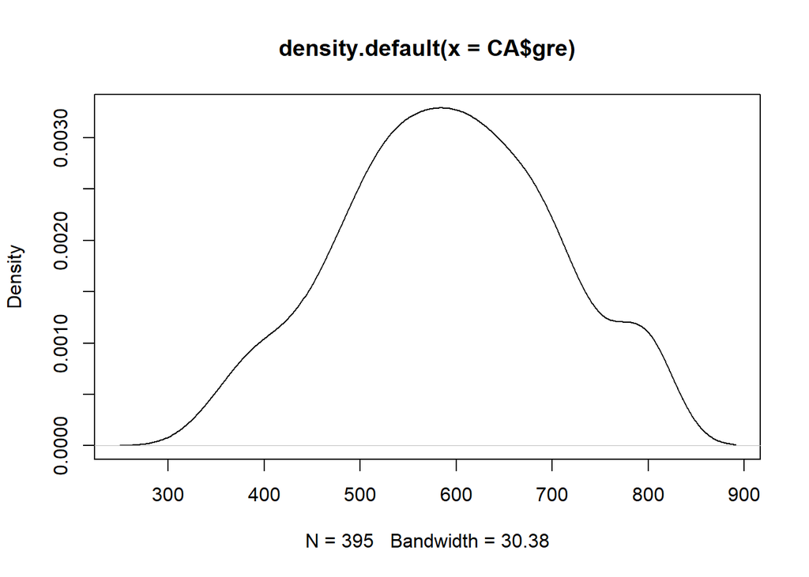

```r
plot(density(CA$gre))
```

### Importing dplyr and ggpubr libraries

```r
library("dplyr")
library("ggpubr")
```

### QQplot is also used to determine if the data is Normally distributed

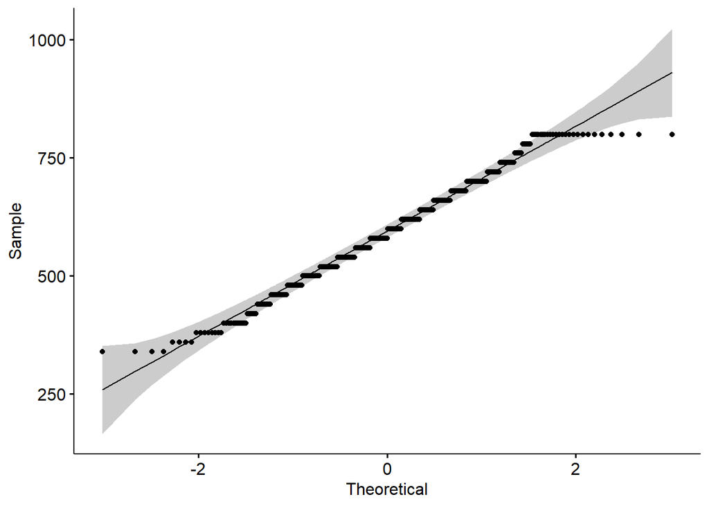

```r
ggqqplot(CA$gre)
```

```r
shapiro.test(CA$gre)
```

```
##
##  Shapiro-Wilk normality test
##
## data:  CA$gre
## W = 0.98282, p-value = 0.0001223
```

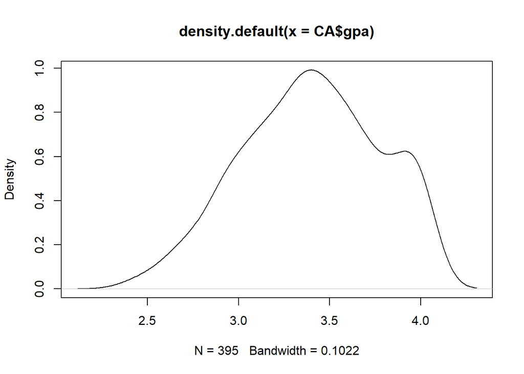

```r
plot(density(CA$gpa))
```

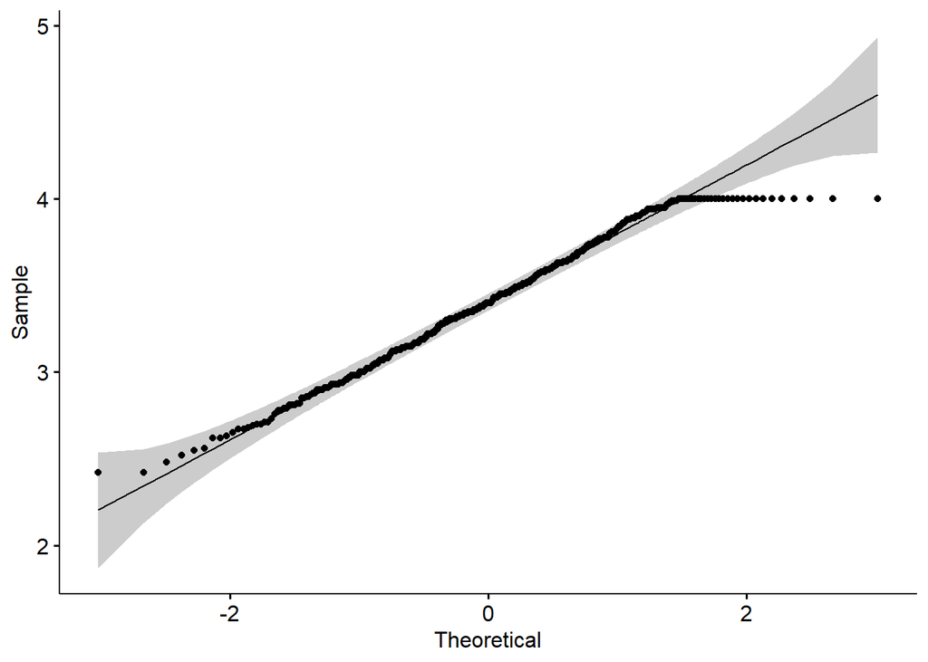

```r
ggqqplot(CA$gpa)
```

### Normality test using shapiro test

```r
shapiro.test(CA$gpa)
```

```
##
##  Shapiro-Wilk normality test
##
## data:  CA$gpa
## W = 0.97646, p-value = 5.004e-06
```

### 5. Normalize the data if not normally distributed

#### But however there is Variance across the numerical Variables, we can clearly see that gre values are in hundred times more than the gpa values. In this case when we build model, gre will intrinsically influence the result more due to its larger value.

#### To avoid the influence of one variable over the other, we can scale down the variables.

#### Creating a copy of the data

```r
ca <- CA
```

```r
CA$gre <- scale(CA$gre, center = T, scale = T)
CA$gpa <- scale(CA$gpa, center = T, scale = T)
head(CA)
```

```
##   admit        gre        gpa ses Gender_Male Race rank
## 1     0 -1.8927212  0.5655683   1           0    3    3
## 2     1  0.6160871  0.7254249   2           0    2    3
## 3     1  1.8704913  1.6046358   2           0    2    1
## 4     1  0.4368865 -0.5534273   1           1    2    4
## 5     0 -0.6383171 -1.2461390   3           1    2    4
## 6     1  1.5120901 -1.0596397   2           1    1    2
```

### 6. Use variable reduction techniques to identify significant variables.

#### We can build logistic regression model and identify significant variables.

#### Step AIC method can also be used for identifying significant variables

```r
set.seed(1234)
train_indices <- sample(1:nrow(CA), 0.70 * nrow(CA))
train <- CA[train_indices, ]
test <- CA[-train_indices,]
test_without_admit <- test[,-1]
```

```r
# fit the model
class(train$admit)
```

```
## [1] "factor"
```

```r
log_reg <- glm(admit ~ . , data = train,
               family = 'binomial')

summary(log_reg)
```

```
##
## Call:
## glm(formula = admit ~ ., family = "binomial", data = train)
##
## Deviance Residuals:
##     Min       1Q   Median       3Q      Max
## -1.8066  -0.9001  -0.6321   1.1700   2.1000
##
## Coefficients:
##              Estimate Std. Error z value Pr(>|z|)
## (Intercept)    0.7439     0.4353   1.709  0.08744 .
## gre            0.3323     0.1510   2.200  0.02780 *
## gpa            0.1571     0.1428   1.100  0.27131
## ses2          -0.1907     0.3228  -0.591  0.55460
## ses3          -0.3870     0.3453  -1.121  0.26243
## Gender_Male1  -0.5257     0.2787  -1.887  0.05922 .
## Race2         -0.4541     0.3422  -1.327  0.18451
## Race3         -0.1639     0.3262  -0.502  0.61533
## rank2         -0.6618     0.3782  -1.750  0.08017 .
## rank3         -1.3225     0.4253  -3.109  0.00188 **
## rank4         -1.6610     0.5096  -3.259  0.00112 **
## ---
## Signif. codes:  0 '***' 0.001 '**' 0.01 '*' 0.05 '.' 0.1 ' ' 1
##
## (Dispersion parameter for binomial family taken to be 1)
##
##     Null deviance: 351.36  on 275  degrees of freedom
## Residual deviance: 319.55  on 265  degrees of freedom
## AIC: 341.55
##
## Number of Fisher Scoring iterations: 4
```

#### Using step AIC method to identify significant variables

```r
library(MASS)
model_AIC = stepAIC(object = log_reg,direction = "both")
```

```
## Start:  AIC=341.55
## admit ~ gre + gpa + ses + Gender_Male + Race + rank
##
##               Df Deviance    AIC
## - ses          2   320.81 338.81
## - Race         2   321.34 339.34
## - gpa          1   320.77 340.77
## <none>             319.55 341.55
## - Gender_Male  1   323.17 343.17
## - gre          1   324.52 344.52
## - rank         3   335.38 351.38
##
## Step:  AIC=338.81
## admit ~ gre + gpa + Gender_Male + Race + rank
##
##               Df Deviance    AIC
## - Race         2   322.82 336.82
## - gpa          1   321.90 337.90
## <none>             320.81 338.81
## - Gender_Male  1   324.45 340.45
## + ses          2   319.55 341.55
## - gre          1   326.03 342.03
## - rank         3   336.99 348.99
##
## Step:  AIC=336.82
## admit ~ gre + gpa + Gender_Male + rank
##
##               Df Deviance    AIC
## - gpa          1   324.15 336.15
## <none>             322.82 336.82
## - Gender_Male  1   325.92 337.92
## + Race         2   320.81 338.81
## + ses          2   321.34 339.34
## - gre          1   327.82 339.82
## - rank         3   338.49 346.49
##
## Step:  AIC=336.15
## admit ~ gre + Gender_Male + rank
##
##               Df Deviance    AIC
## <none>             324.15 336.15
## + gpa          1   322.82 336.82
## - Gender_Male  1   327.29 337.29
## + Race         2   321.90 337.90
## + ses          2   322.78 338.78
## - gre          1   331.83 341.83
## - rank         3   339.64 345.64
```

```r
summary(model_AIC)
```

```
##
## Call:
## glm(formula = admit ~ gre + Gender_Male + rank, family = "binomial",
##     data = train)
##
## Deviance Residuals:
##     Min       1Q   Median       3Q      Max
## -1.6457  -0.8999  -0.6500   1.1699   2.1324
##
## Coefficients:
##              Estimate Std. Error z value Pr(>|z|)
## (Intercept)    0.3377     0.3443   0.981  0.32665
## gre            0.3838     0.1412   2.717  0.00659 **
## Gender_Male1  -0.4804     0.2731  -1.759  0.07860 .
## rank2         -0.6469     0.3706  -1.746  0.08089 .
## rank3         -1.2689     0.4157  -3.053  0.00227 **
## rank4         -1.6397     0.5015  -3.269  0.00108 **
## ---
## Signif. codes:  0 '***' 0.001 '**' 0.01 '*' 0.05 '.' 0.1 ' ' 1
##
## (Dispersion parameter for binomial family taken to be 1)
##
##     Null deviance: 351.36  on 275  degrees of freedom
## Residual deviance: 324.15  on 270  degrees of freedom
## AIC: 336.15
##
## Number of Fisher Scoring iterations: 4
```

### 7. Run logistic model to determine the factors that influence the admission process of a student (Drop insignificant variables)

```r
summary(log_reg)
```

```
##
## Call:
## glm(formula = admit ~ ., family = "binomial", data = train)
##
## Deviance Residuals:
##     Min       1Q   Median       3Q      Max
## -1.8066  -0.9001  -0.6321   1.1700   2.1000
##
## Coefficients:
##              Estimate Std. Error z value Pr(>|z|)
## (Intercept)    0.7439     0.4353   1.709  0.08744 .
## gre            0.3323     0.1510   2.200  0.02780 *
## gpa            0.1571     0.1428   1.100  0.27131
## ses2          -0.1907     0.3228  -0.591  0.55460
## ses3          -0.3870     0.3453  -1.121  0.26243
## Gender_Male1  -0.5257     0.2787  -1.887  0.05922 .
## Race2         -0.4541     0.3422  -1.327  0.18451
## Race3         -0.1639     0.3262  -0.502  0.61533
## rank2         -0.6618     0.3782  -1.750  0.08017 .
## rank3         -1.3225     0.4253  -3.109  0.00188 **
## rank4         -1.6610     0.5096  -3.259  0.00112 **
## ---
## Signif. codes:  0 '***' 0.001 '**' 0.01 '*' 0.05 '.' 0.1 ' ' 1
##
## (Dispersion parameter for binomial family taken to be 1)
##
##     Null deviance: 351.36  on 275  degrees of freedom
## Residual deviance: 319.55  on 265  degrees of freedom
## AIC: 341.55
##
## Number of Fisher Scoring iterations: 4
```

### 8. Calculate the accuracy of the model and run validation techniques

#### Using the result of logistic regresssion model to calculate the accuracy

```r
head(CA)
```

```
##   admit        gre        gpa ses Gender_Male Race rank
## 1     0 -1.8927212  0.5655683   1           0    3    3
## 2     1  0.6160871  0.7254249   2           0    2    3
## 3     1  1.8704913  1.6046358   2           0    2    1
## 4     1  0.4368865 -0.5534273   1           1    2    4
## 5     0 -0.6383171 -1.2461390   3           1    2    4
## 6     1  1.5120901 -1.0596397   2           1    1    2
```

```r
DWSV <- CA[,c(1,2,3,7)]
class(DWSV)
```

```
## [1] "data.frame"
```

```r
head(DWSV)
```

```
##   admit        gre        gpa rank
## 1     0 -1.8927212  0.5655683    3
## 2     1  0.6160871  0.7254249    3
## 3     1  1.8704913  1.6046358    1
## 4     1  0.4368865 -0.5534273    4
## 5     0 -0.6383171 -1.2461390    4
## 6     1  1.5120901 -1.0596397    2
```

```r
set.seed(123)
ti <- sample(1:nrow(DWSV), 0.70 * nrow(DWSV))
Train <- DWSV[ti, ]
Test <- DWSV[-ti,]
test_without_admit <- Test[,-1]
```

```r
log_reg <- glm(admit ~ . , data = Train,
               family = 'binomial')

summary(log_reg)
```

```
##
## Call:
## glm(formula = admit ~ ., family = "binomial", data = Train)
##
## Deviance Residuals:
##     Min       1Q   Median       3Q      Max
## -1.6561  -0.9002  -0.7022   1.2076   1.9766
##
## Coefficients:
##             Estimate Std. Error z value Pr(>|z|)
## (Intercept)   0.1675     0.3310   0.506  0.61297
## gre           0.2642     0.1481   1.783  0.07451 .
## gpa           0.2736     0.1497   1.827  0.06772 .
## rank2        -0.7515     0.3897  -1.929  0.05376 .
## rank3        -1.2300     0.4211  -2.921  0.00349 **
## rank4        -1.3930     0.4799  -2.903  0.00370 **
## ---
## Signif. codes:  0 '***' 0.001 '**' 0.01 '*' 0.05 '.' 0.1 ' ' 1
##
## (Dispersion parameter for binomial family taken to be 1)
##
##     Null deviance: 352.73  on 275  degrees of freedom
## Residual deviance: 331.08  on 270  degrees of freedom
## AIC: 343.08
##
## Number of Fisher Scoring iterations: 4
```

#### Importing library MASS and CARET

#### Predicting on test data and caluculating the accuracy using confusion matrix

```r
library(MASS)
library(caret)
prob_train <- predict(log_reg,newdata = Test[,-1], type = "response")
preds_train <- ifelse(prob_train > 0.49,1,0) # use 0.5 or 0.49 to get the best accuracy
comp = table(Test$admit,preds_train)
confusionMatrix(comp,positive = "0")
```

```
## Confusion Matrix and Statistics
##
##    preds_train
##      0  1
##   0 76 10
##   1 20 13
##
##                Accuracy : 0.7479
##                  95% CI : (0.6601, 0.823)
##     No Information Rate : 0.8067
##     P-Value [Acc > NIR] : 0.9555
##
##                   Kappa : 0.3063
##
##  Mcnemar's Test P-Value : 0.1003
##
##             Sensitivity : 0.7917
##             Specificity : 0.5652
##          Pos Pred Value : 0.8837
##          Neg Pred Value : 0.3939
##              Prevalence : 0.8067
##          Detection Rate : 0.6387
##    Detection Prevalence : 0.7227
##       Balanced Accuracy : 0.6784
##
##        'Positive' Class : 0
##
```

### 9. Try other modelling techniques like decision tree and SVM and select a champion model

### Decision Tree

#### Using library C50

```r
library(C50)
```

### Building the model and printing the summary

```r
c5_tree <- C5.0(admit~., Train, rules = T)
c5_tree
```

```
##
## Call:
## C5.0.formula(formula = admit ~ ., data = Train, rules = T)
##
## Rule-Based Model
## Number of samples: 276
## Number of predictors: 3
##
## Number of Rules: 7
##
## Non-standard options: attempt to group attributes
```

```r
summary(c5_tree)
```

```
##
## Call:
## C5.0.formula(formula = admit ~ ., data = Train, rules = T)
##
##
## C5.0 [Release 2.07 GPL Edition]      Tue Jul 07 15:16:59 2020
## -------------------------------
##
## Class specified by attribute `outcome'
##
## Read 276 cases (4 attributes) from undefined.data
##
## Rules:
##
## Rule 1: (10, lift 1.4)
##  gre > 0.7952877
##  gre <= 0.9744883
##  rank = 2
##  ->  class 0  [0.917]
##
## Rule 2: (119/29, lift 1.1)
##  gpa <= -0.153786
##  ->  class 0  [0.752]
##
## Rule 3: (163/41, lift 1.1)
##  gre <= 0.4368865
##  rank in {2, 3, 4}
##  ->  class 0  [0.745]
##
## Rule 4: (129/33, lift 1.1)
##  rank in {3, 4}
##  ->  class 0  [0.740]
##
## Rule 5: (22/5, lift 2.2)
##  gpa > -0.153786
##  rank = 1
##  ->  class 1  [0.750]
##
## Rule 6: (11/3, lift 2.1)
##  gre > 0.9744883
```

[output cut: 20 more lines]

```
##
##     (a)   (b)    <-classified as
##    ----  ----
##     173    10    (a): class 0
##      64    29    (b): class 1
##
##
##  Attribute usage:
##
##   93.84% rank
##   71.74% gre
##   51.09% gpa
##
##
## Time: 0.0 secs
```

#### Predicting on test data

```r
probdt <- predict(c5_tree, Test[,-1])
probdt
```

```
##   [1] 0 1 0 0 0 1 0 0 1 0 0 0 0 0 0 0 0 0 0 0 0 0 0 0 1 0 0 1 0 0 0 0 0 0 0 0 0
##  [38] 0 0 0 0 0 1 0 0 0 0 0 0 0 0 0 0 0 0 0 0 0 0 0 0 0 0 0 0 1 1 0 0 0 0 0 1 0
##  [75] 0 0 0 0 0 0 0 0 0 0 0 0 1 0 1 0 0 0 0 0 0 1 0 0 1 0 0 1 0 0 0 0 1 0 1 1 0
## [112] 0 0 0 0 1 0 0 0
## Levels: 0 1
```

#### Using confusion matric to calculate accuracy

```r
confusionMatrix(probdt,Test$admit)
```

```
## Confusion Matrix and Statistics
##
##           Reference
## Prediction  0  1
##          0 80 21
##          1  6 12
##
##                Accuracy : 0.7731
##                  95% CI : (0.6873, 0.8448)
##     No Information Rate : 0.7227
##     P-Value [Acc > NIR] : 0.129005
##
##                   Kappa : 0.3417
##
##  Mcnemar's Test P-Value : 0.007054
##
##             Sensitivity : 0.9302
##             Specificity : 0.3636
##          Pos Pred Value : 0.7921
##          Neg Pred Value : 0.6667
##              Prevalence : 0.7227
##          Detection Rate : 0.6723
##    Detection Prevalence : 0.8487
##       Balanced Accuracy : 0.6469
##
##        'Positive' Class : 0
##
```

#### Decision Tree using rpart

```r
library(rpart)
```

#### Model Building

```r
dtr <- rpart(admit~., data = Train)
print(dtr)
```

```
## n= 276
##
## node), split, n, loss, yval, (yprob)
##       * denotes terminal node
##
##   1) root 276 93 0 (0.6630435 0.3369565)
##     2) gpa< 0.3124622 174 45 0 (0.7413793 0.2586207)
##       4) rank=3,4 78 13 0 (0.8333333 0.1666667) *
##       5) rank=1,2 96 32 0 (0.6666667 0.3333333)
##        10) gre< 1.064089 88 26 0 (0.7045455 0.2954545)
##          20) gpa>=0.2591767 7  0 0 (1.0000000 0.0000000) *
##          21) gpa< 0.2591767 81 26 0 (0.6790123 0.3209877)
##            42) gpa< 0.09932014 71 20 0 (0.7183099 0.2816901) *
##            43) gpa>=0.09932014 10  4 1 (0.4000000 0.6000000) *
##        11) gre>=1.064089 8  2 1 (0.2500000 0.7500000) *
##     3) gpa>=0.3124622 102 48 0 (0.5294118 0.4705882)
##       6) rank=2,3,4 83 34 0 (0.5903614 0.4096386)
##        12) gre< 1.51209 73 28 0 (0.6164384 0.3835616)
##          24) gre>=0.884888 14  2 0 (0.8571429 0.1428571) *
##          25) gre< 0.884888 59 26 0 (0.5593220 0.4406780)
##            50) gre< 0.5264868 45 16 0 (0.6444444 0.3555556)
##             100) gre>=-0.3695162 26  6 0 (0.7692308 0.2307692) *
##             101) gre< -0.3695162 19  9 1 (0.4736842 0.5263158) *
##            51) gre>=0.5264868 14  4 1 (0.2857143 0.7142857) *
##        13) gre>=1.51209 10  4 1 (0.4000000 0.6000000) *
##       7) rank=1 19  5 1 (0.2631579 0.7368421) *
```

#### Plotting decision tree

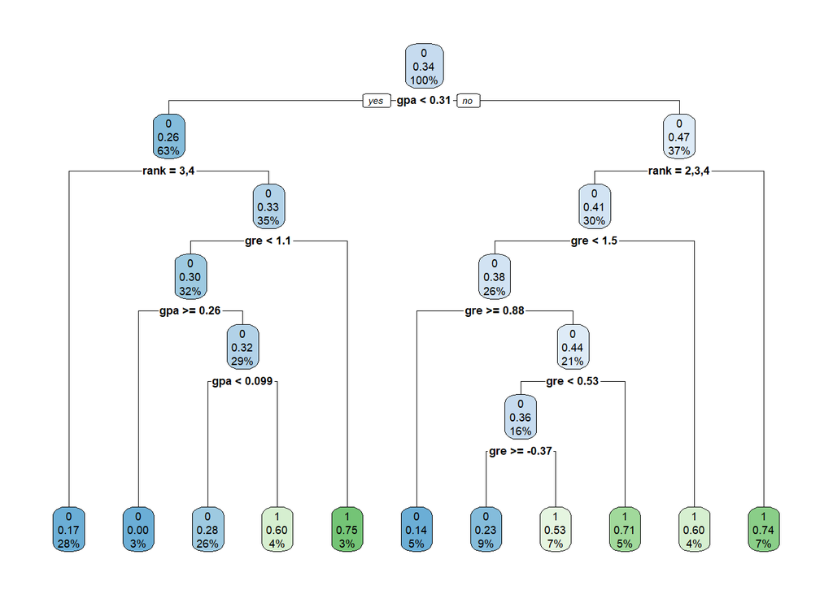

```r
library(rpart.plot)
rpart.plot(dtr)
```

#### Predicting on test data and using confusion matrix to calculate accuracy

```r
pred_class <- predict(dtr, newdata = Test[,-1], type = 'class')
caret::confusionMatrix(pred_class, Test$admit, positive = '0')
```

```
## Confusion Matrix and Statistics
##
##           Reference
## Prediction  0  1
##          0 68 13
##          1 18 20
##
##                Accuracy : 0.7395
##                  95% CI : (0.6511, 0.8156)
##     No Information Rate : 0.7227
##     P-Value [Acc > NIR] : 0.3847
##
##                   Kappa : 0.3791
##
##  Mcnemar's Test P-Value : 0.4725
##
##             Sensitivity : 0.7907
##             Specificity : 0.6061
##          Pos Pred Value : 0.8395
##          Neg Pred Value : 0.5263
##              Prevalence : 0.7227
##          Detection Rate : 0.5714
##    Detection Prevalence : 0.6807
##       Balanced Accuracy : 0.6984
##
##        'Positive' Class : 0
##
```

### Random Forest

```r
library(randomForest)
```

#### Model Building

```r
rf = randomForest(admit~.,Train,keep.forest = TRUE,ntree = 100,norm.votes = TRUE,maxnodes = 100)
summary(rf)
```

```
##                 Length Class  Mode
## call              7    -none- call
## type              1    -none- character
## predicted       276    factor numeric
## err.rate        300    -none- numeric
## confusion         6    -none- numeric
## votes           552    matrix numeric
## oob.times       276    -none- numeric
## classes           2    -none- character
## importance        3    -none- numeric
## importanceSD      0    -none- NULL
## localImportance   0    -none- NULL
## proximity         0    -none- NULL
## ntree             1    -none- numeric
## mtry              1    -none- numeric
## forest           14    -none- list
## y               276    factor numeric
## test              0    -none- NULL
## inbag             0    -none- NULL
## terms             3    terms  call
```

```r
print(rf)
```

```
##
## Call:
##  randomForest(formula = admit ~ ., data = Train, keep.forest = TRUE,      ntree = 100, norm.votes = TRUE, maxnodes = 100)
##                Type of random forest: classification
##                      Number of trees: 100
## No. of variables tried at each split: 1
##
##         OOB estimate of  error rate: 32.25%
## Confusion matrix:
##     0  1 class.error
## 0 163 20   0.1092896
## 1  69 24   0.7419355
```

#### Using the model to predict on test data and using confusion matrix to calculate accuracy

```r
pred_rf1 <- predict(rf,Test[,-1],type = "Class")
confusionMatrix(pred_rf1,Test$admit)
```

```
## Confusion Matrix and Statistics
##
##           Reference
## Prediction  0  1
##          0 80 23
##          1  6 10
##
##                Accuracy : 0.7563
##                  95% CI : (0.6691, 0.8303)
##     No Information Rate : 0.7227
##     P-Value [Acc > NIR] : 0.239155
##
##                   Kappa : 0.2773
##
##  Mcnemar's Test P-Value : 0.002967
##
##             Sensitivity : 0.9302
##             Specificity : 0.3030
##          Pos Pred Value : 0.7767
##          Neg Pred Value : 0.6250
##              Prevalence : 0.7227
##          Detection Rate : 0.6723
##    Detection Prevalence : 0.8655
##       Balanced Accuracy : 0.6166
##
##        'Positive' Class : 0
##
```

```r
table(pred_rf1)
```

```
## pred_rf1
##   0   1
## 103  16
```

### SUpport Vector Machines

```r
library(e1071)
```

#### Model Building

```r
model_svm = svm(admit~.,Train,kernel = "linear")
summary(model_svm)
```

```
##
## Call:
## svm(formula = admit ~ ., data = Train, kernel = "linear")
##
##
## Parameters:
##    SVM-Type:  C-classification
##  SVM-Kernel:  linear
##        cost:  1
##
## Number of Support Vectors:  197
##
##  ( 104 93 )
##
##
## Number of Classes:  2
##
## Levels:
##  0 1
```

#### Using the SVM model to predict on test data and also calculate accuracy using confusion matrix

```r
pred_svm <- predict(model_svm,Test[,-1],type = "Class")
confusionMatrix(pred_svm,Test$admit)
```

```
## Confusion Matrix and Statistics
##
##           Reference
## Prediction  0  1
##          0 76 21
##          1 10 12
##
##                Accuracy : 0.7395
##                  95% CI : (0.6511, 0.8156)
##     No Information Rate : 0.7227
##     P-Value [Acc > NIR] : 0.38474
##
##                   Kappa : 0.2757
##
##  Mcnemar's Test P-Value : 0.07249
##
##             Sensitivity : 0.8837
##             Specificity : 0.3636
##          Pos Pred Value : 0.7835
##          Neg Pred Value : 0.5455
##              Prevalence : 0.7227
##          Detection Rate : 0.6387
##    Detection Prevalence : 0.8151
##       Balanced Accuracy : 0.6237
##
##        'Positive' Class : 0
##
```

```r
table(pred_svm)
```

```
## pred_svm
##  0  1
## 97 22
```

### 10. Determine the accuracy rates for each kind of model

#### a) Logistic Regression : 74.79%

#### b) Decision Tree (C50) : 77.31%

#### c) Decision Tree (rpart) : 73.95%

#### d) Random Forest : 75.63%

#### e) SVM : 73.95%

### 11. Select the most accurate model

#### Decision Tree using library C50 is giving better results compared to other models

### 12. Identify other Machine learning or statistical techniques

#### 1.I have already used Randome Forest. Other than random forest, we can apply Naive Bayes and Boosting Algorithms.

### Naive Bayes

```r
Naive_bayes <- naiveBayes(admit~.,Train)
Naive_bayes
```

```
##
## Naive Bayes Classifier for Discrete Predictors
##
## Call:
## naiveBayes.default(x = X, y = Y, laplace = laplace)
##
## A-priori probabilities:
## Y
##         0         1
## 0.6630435 0.3369565
##
## Conditional probabilities:
##    gre
## Y          [,1]      [,2]
##   0 -0.08896441 0.9601869
##   1  0.23456326 0.9618459
##
##    gpa
## Y        [,1]      [,2]
##   0 -0.120883 0.9490892
##   1  0.189705 0.9816050
##
##    rank
## Y            1          2          3          4
##   0 0.09836066 0.37704918 0.31693989 0.20765027
##   1 0.22580645 0.41935484 0.23655914 0.11827957
```

```r
pred_nb <- predict(Naive_bayes,Test[,-1])
confusionMatrix(pred_nb,Test$admit)
```

```
## Confusion Matrix and Statistics
##
##           Reference
## Prediction  0  1
##          0 75 19
##          1 11 14
##
##                Accuracy : 0.7479
##                  95% CI : (0.6601, 0.823)
##     No Information Rate : 0.7227
##     P-Value [Acc > NIR] : 0.3084
##
##                   Kappa : 0.3203
##
##  Mcnemar's Test P-Value : 0.2012
##
##             Sensitivity : 0.8721
##             Specificity : 0.4242
##          Pos Pred Value : 0.7979
##          Neg Pred Value : 0.5600
##              Prevalence : 0.7227
##          Detection Rate : 0.6303
##    Detection Prevalence : 0.7899
##       Balanced Accuracy : 0.6482
##
##        'Positive' Class : 0
##
```

```r
table(pred_nb)
```

```
## pred_nb
##  0  1
## 94 25
```

```r
train.control <- trainControl(method = "repeatedcv", number = 5, repeats = 3)
model_xgbTree <- train(admit ~ .,data=Train, method = "xgbTree", trControl = train.control)
print(model_xgbTree)
```

```
## eXtreme Gradient Boosting
##
## 276 samples
##   3 predictor
##   2 classes: '0', '1'
##
## No pre-processing
## Resampling: Cross-Validated (5 fold, repeated 3 times)
## Summary of sample sizes: 220, 221, 220, 221, 222, 220, ...
## Resampling results across tuning parameters:
##
##   eta  max_depth  colsample_bytree  subsample  nrounds  Accuracy   Kappa
##   0.3  1          0.6               0.50        50      0.6536524  0.11068270
##   0.3  1          0.6               0.50       100      0.6523337  0.12183424
##   0.3  1          0.6               0.50       150      0.6343667  0.11165009
##   0.3  1          0.6               0.75        50      0.6644749  0.12722152
##   0.3  1          0.6               0.75       100      0.6525509  0.12114774
##   0.3  1          0.6               0.75       150      0.6440212  0.12135496
##   0.3  1          0.6               1.00        50      0.6559668  0.10521439
##   0.3  1          0.6               1.00       100      0.6571805  0.11506982
##   0.3  1          0.6               1.00       150      0.6609043  0.13343016
##   0.3  1          0.8               0.50        50      0.6451876  0.11013122
##   0.3  1          0.8               0.50       100      0.6523753  0.13962549
##   0.3  1          0.8               0.50       150      0.6464005  0.13561934
##   0.3  1          0.8               0.75        50      0.6524194  0.10817446
##   0.3  1          0.8               0.75       100      0.6427866  0.10246518
##   0.3  1          0.8               0.75       150      0.6536756  0.13853972
##   0.3  1          0.8               1.00        50      0.6522872  0.09294496
##   0.3  1          0.8               1.00       100      0.6547996  0.10540616
##   0.3  1          0.8               1.00       150      0.6584359  0.12418774
##   0.3  2          0.6               0.50        50      0.6427650  0.11494663
##   0.3  2          0.6               0.50       100      0.6272014  0.10543649
##   0.3  2          0.6               0.50       150      0.6223112  0.09263405
##   0.3  2          0.6               0.75        50      0.6368118  0.09988173
##   0.3  2          0.6               0.75       100      0.6368110  0.12657983
##   0.3  2          0.6               0.75       150      0.6148814  0.07963074
##   0.3  2          0.6               1.00        50      0.6355548  0.09530647
##   0.3  2          0.6               1.00       100      0.6282155  0.08921382
##   0.3  2          0.6               1.00       150      0.6305748  0.11209129
##   0.3  2          0.8               0.50        50      0.6401884  0.12656338
```

[output cut: 73 more lines]

```
##   0.4  3          0.8               0.50       150      0.6184303  0.10074361
##   0.4  3          0.8               0.75        50      0.6246224  0.10252713
##   0.4  3          0.8               0.75       100      0.6211175  0.10967365
##   0.4  3          0.8               0.75       150      0.6318959  0.14243187
##   0.4  3          0.8               1.00        50      0.6268254  0.10745202
##   0.4  3          0.8               1.00       100      0.6243571  0.12064126
##   0.4  3          0.8               1.00       150      0.6243803  0.12672106
##
## Tuning parameter 'gamma' was held constant at a value of 0
## Tuning
##  parameter 'min_child_weight' was held constant at a value of 1
## Accuracy was used to select the optimal model using the largest value.
## The final values used for the model were nrounds = 100, max_depth = 1, eta
##  = 0.4, gamma = 0, colsample_bytree = 0.6, min_child_weight = 1 and subsample
##  = 1.
```

```r
pred_xgboost <- predict(model_xgbTree,Test[,-1])
confusionMatrix(pred_xgboost,Test$admit)
```

```
## Confusion Matrix and Statistics
##
##           Reference
## Prediction  0  1
##          0 76 23
##          1 10 10
##
##                Accuracy : 0.7227
##                  95% CI : (0.6332, 0.8008)
##     No Information Rate : 0.7227
##     P-Value [Acc > NIR] : 0.54673
##
##                   Kappa : 0.2126
##
##  Mcnemar's Test P-Value : 0.03671
##
##             Sensitivity : 0.8837
##             Specificity : 0.3030
##          Pos Pred Value : 0.7677
##          Neg Pred Value : 0.5000
##              Prevalence : 0.7227
##          Detection Rate : 0.6387
##    Detection Prevalence : 0.8319
##       Balanced Accuracy : 0.5934
##
##        'Positive' Class : 0
##
```

```r
table(pred_xgboost)
```

```
## pred_xgboost
##  0  1
## 99 20
```

#### 2. We can use Chi-Square to check for the independence of the categorical variables.

### Descriptive:

GRE Categorized 0-440 Low 440-580 Medium 580+ High

```r
head(ca)
```

```
##   admit gre  gpa ses Gender_Male Race rank
## 1     0 380 3.61   1           0    3    3
## 2     1 660 3.67   2           0    2    3
## 3     1 800 4.00   2           0    2    1
## 4     1 640 3.19   1           1    2    4
## 5     0 520 2.93   3           1    2    4
## 6     1 760 3.00   2           1    1    2
```

```r
library(psych)
ca$Category[ca$gre >= 440 | ca$gre < 580] = "Medium"
ca$Category[ca$gre < 440] = "Low"
ca$Category[ca$gre >= 580               ] = "High"
ca
```

```
##     admit gre  gpa ses Gender_Male Race rank Category
## 1       0 380 3.61   1           0    3    3      Low
## 2       1 660 3.67   2           0    2    3     High
## 3       1 800 4.00   2           0    2    1     High
## 4       1 640 3.19   1           1    2    4     High
## 5       0 520 2.93   3           1    2    4   Medium
## 6       1 760 3.00   2           1    1    2     High
## 7       1 560 2.98   2           1    2    1   Medium
## 8       0 400 3.08   2           0    2    2      Low
## 9       1 540 3.39   1           1    1    3   Medium
## 10      0 700 3.92   1           0    2    2     High
## 11      0 800 4.00   1           1    1    4     High
## 12      0 440 3.22   3           0    2    1   Medium
## 13      1 760 4.00   3           1    2    1     High
## 14      0 700 3.08   2           0    2    2     High
```

[output cut: 381 more lines]

```r
ca$Category <- as.factor(ca$Category)
str(ca)
```

```
## 'data.frame':    395 obs. of  8 variables:
##  $ admit      : Factor w/ 2 levels "0","1": 1 2 2 2 1 2 2 1 2 1 ...
##  $ gre        : int  380 660 800 640 520 760 560 400 540 700 ...
##  $ gpa        : num  3.61 3.67 4 3.19 2.93 3 2.98 3.08 3.39 3.92 ...
##  $ ses        : Factor w/ 3 levels "1","2","3": 1 2 2 1 3 2 2 2 1 1 ...
##  $ Gender_Male: Factor w/ 2 levels "0","1": 1 1 1 2 2 2 2 1 2 1 ...
##  $ Race       : Factor w/ 3 levels "1","2","3": 3 2 2 2 2 1 2 2 1 2 ...
##  $ rank       : Factor w/ 4 levels "1","2","3","4": 3 3 1 4 4 2 1 2 3 2 ...
##  $ Category   : Factor w/ 3 levels "High","Low","Medium": 2 1 1 1 3 1 3 2 3 1 ...
```

```r
summary(ca$Category)
```

```
##   High    Low Medium
##    226     33    136
```

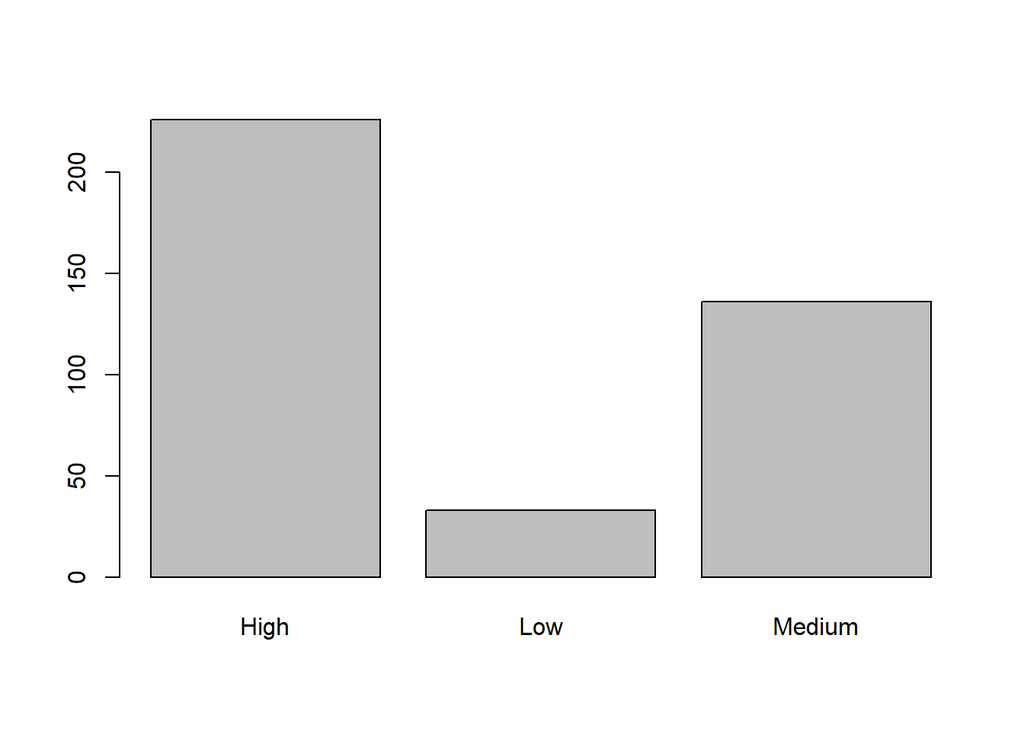

```r
plot(ca$Category)
```